# San Francisco 49ers Offense: Scouting Report

**Public data.** Built from nflverse (nflfastR play-by-play, NGS participation, FTN charting), mapped onto the PFF GamePBP layout. Run concepts, PFF success codes, yards after contact and receiver alignment are not in this source; see *What nflverse cannot cover* at the end.

**Sample:** 19 games (Sep 07, 2025 to Jan 17, 2026) · 1158 offensive plays · Opponents: ARZ, ATL, CAR, CHI, CLV, HST, IND, JAX, LA, NO, NYG, PHI, SEA, TB, TEN  
**Source:** SF_2025_nflverse_GamePBP.csv · Generated Nov 05, 2026 16:45 · Success = standard yardage definition · EPA = nflfastR model

59%Pass rate

52%Neutral early-down pass rate

+0.07EPA / play

53%Success rate

50%3rd-down conversion

4%Sack rate

8%Explosive play rate

## Key findings

### Tendencies

- Passes on 59% of all plays and 52% of neutral early-down plays (1st/2nd down, outside 2-minute drills).
- QB alignment is a strong run/pass key: under center they run 66% of the time (n=522); in shotgun they pass 83% (n=610).
- Pistol is a real part of the menu: 26 plays, 35% pass.
- Base personnel is 11 (44% of snaps, 74% pass). 4 groupings reach 10+ plays.
- Tell: 3rd Down + Long (7-10) -> pass 95% of the time (n=56, 95% lower bound 85%).
- Tell: Shotgun + 3rd Down -> pass 89% of the time (n=190, 95% lower bound 84%).
- Tell: 3rd Down + Medium (4-6) -> pass 92% of the time (n=63, 95% lower bound 83%).
- Tell: 11 + Shotgun -> pass 86% of the time (n=390, 95% lower bound 82%).
- Run game is built on Middle and Left Guard: 41% of carries.
- Predictability: knowing personnel, alignment, down and distance lifts a defense’s run/pass guess from 59% to 74% (leave-one-out).

### Strengths

- Most efficient run gap: Middle, +0.12 EPA/carry, 4.0 YPC, 61% success (n=125).
- Primary target: C. McCaffrey (#23) (HB), 24% target share, 113 catches for 1009 yards, +0.33 EPA/target, 55 first downs.
- Most efficient receiver: G. Kittle (#85) (TE), +0.65 EPA/target on 71 targets, aDOT 6.7, 4.4 YAC/rec.
- Lead back C. McCaffrey (#23): 72% of carries, 3.8 YPC, 49% success. Favorite gap: Middle.
- Most total value: G. Kittle (#85), 44.9 total EPA on 72 touches + targets (631 scrimmage yards).
- Deep shots (20+ air yards): 10% of targets, 44% complete, +0.35 EPA/target (n=59).

### Vulnerabilities

- Play action: 22% of dropbacks, +0.09 EPA/play vs +0.16 without (n=153 vs 536).
- Pressure breaks the passing game: -0.48 EPA/dropback when pressured vs +0.35 clean. Pressured on 25% of dropbacks; sack rate 4%.
- Least efficient run gap: Right End, -0.19 EPA/carry, stuffed (0 or fewer yards) on 25% (n=55).
- On 3rd and Extra Long (11+) they convert only 30% (n=33); they pass 91% of the time there. Overall 3rd-down conversion: 50%.
- Least productive personnel: 12, -0.03 EPA/play (n=125, 48% pass).
- High-volume, low-return target: J. Jennings (#15) (WR), 16% of targets but +0.00 EPA/target and 60% catch rate.

**n** = the number of plays (or carries / targets) behind a number, i.e. the sample size. Findings are generated by fixed rules (see Methodology) and include sample sizes. Treat any rate built on fewer than 10 plays as anecdotal.

## 1. Personnel run/pass tendencies

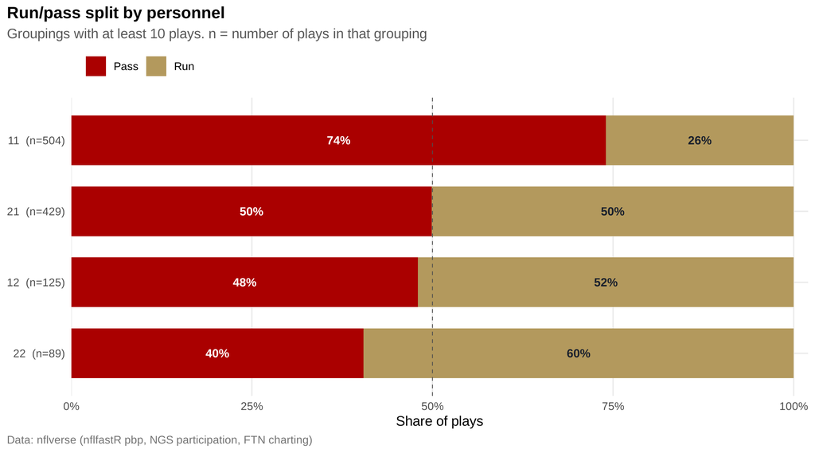

| Personnel | Plays | Snap % | Pass % | Pass % 95% CI | Run EPA | Pass EPA | Success |
| --- | --- | --- | --- | --- | --- | --- | --- |
| 11 | 504 | 44% | 74% | 70%-78% | -0.06 | +0.14 | 48% |
| 21 | 429 | 37% | 50% | 45%-55% | -0.04 | +0.21 | 57% |
| 12 | 125 | 11% | 48% | 39%-57% | -0.06 | +0.01 | 53% |
| 22 | 89 | 8% | 40% | 31%-51% | -0.00 | -0.03 | 64% |
| 23 | 9 | 1% | 44% | 19%-73% | -0.08 | +0.40 | 56% |
| 13 | 2 | 0% | 100% | 34%-100% | n/a | -0.25 | 50% |

## 2. Down-and-distance tendencies

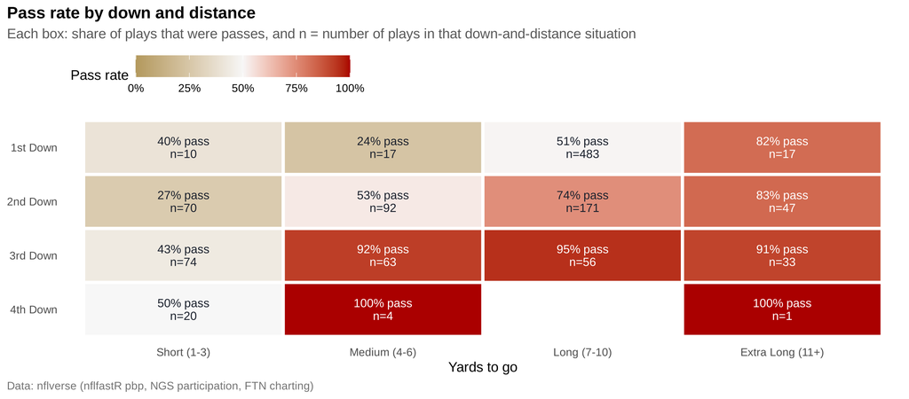

| Down | To go | Plays | Pass % | Run EPA | Pass EPA | Success |
| --- | --- | --- | --- | --- | --- | --- |
| 1st Down | Short (1-3) | 10 | 40% | +0.05 | +0.21 | 60% |
| 1st Down | Medium (4-6) | 17 | 24% | +0.18 | +1.03 | 65% |
| 1st Down | Long (7-10) | 483 | 51% | -0.11 | +0.04 | 55% |
| 1st Down | Extra Long (11+) | 17 | 82% | +0.09 | +0.30 | 53% |
| 2nd Down | Short (1-3) | 70 | 27% | +0.01 | +0.18 | 69% |
| 2nd Down | Medium (4-6) | 92 | 53% | +0.04 | +0.16 | 60% |
| 2nd Down | Long (7-10) | 171 | 74% | -0.25 | +0.11 | 43% |
| 2nd Down | Extra Long (11+) | 47 | 83% | -0.35 | +0.33 | 40% |
| 3rd Down | Short (1-3) | 74 | 43% | +0.07 | +0.26 | 64% |
| 3rd Down | Medium (4-6) | 63 | 92% | +0.22 | +0.16 | 51% |
| 3rd Down | Long (7-10) | 56 | 95% | +0.57 | +0.38 | 45% |
| 3rd Down | Extra Long (11+) | 33 | 91% | -0.05 | +0.51 | 30% |
| 4th Down | Short (1-3) | 20 | 50% | +0.92 | -0.18 | 65% |
| 4th Down | Medium (4-6) | 4 | 100% | n/a | -2.35 | 0% |
| 4th Down | Extra Long (11+) | 1 | 100% | n/a | -0.15 | 0% |

**By field position** (yards from the opponent’s end zone):

| Zone | Plays | Pass % | EPA/play | Success |
| --- | --- | --- | --- | --- |
| Goal to Go (1-10) | 96 | 53% | +0.31 | 56% |
| Red Zone (11-20) | 110 | 51% | +0.10 | 46% |
| Plus Territory (21-50) | 427 | 53% | +0.02 | 53% |
| Own Territory (51-80) | 459 | 68% | +0.04 | 53% |
| Backed Up (81-99) | 66 | 64% | +0.14 | 55% |

## 3. QB alignment tendencies

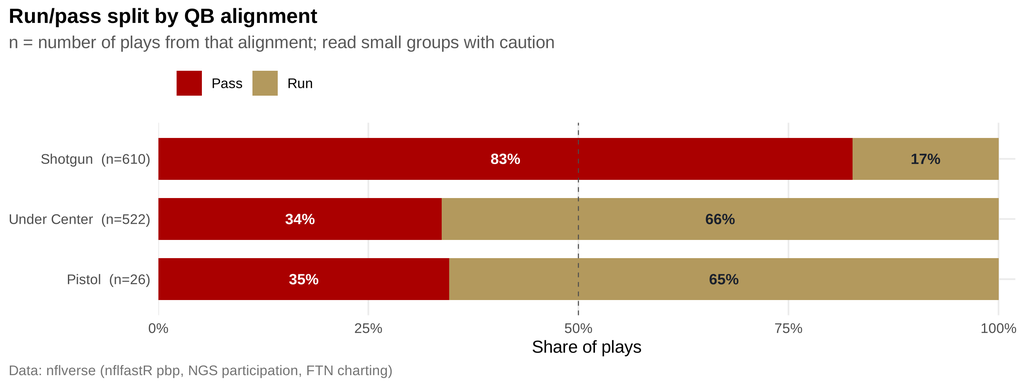

| Alignment | Plays | Snap % | Pass % | Run EPA | Pass EPA | Run YPC | Pass Y/P |
| --- | --- | --- | --- | --- | --- | --- | --- |
| Under Center | 522 | 45% | 34% | -0.03 | +0.12 | 3.7 | 7.3 |
| Shotgun | 610 | 53% | 83% | -0.10 | +0.15 | 3.7 | 6.8 |
| Pistol | 26 | 2% | 35% | -0.01 | +0.37 | 3.9 | 9.7 |

**Alignment by personnel** (groupings with enough plays):

| Personnel | Alignment | Plays | Pass % | EPA/play |
| --- | --- | --- | --- | --- |
| 11 | Under Center | 107 | 31% | -0.01 |
| 11 | Shotgun | 390 | 86% | +0.12 |
| 11 | Pistol | 7 | 71% | -0.24 |
| 12 | Under Center | 87 | 40% | -0.05 |
| 12 | Shotgun | 35 | 71% | -0.00 |
| 21 | Under Center | 252 | 34% | +0.10 |
| 21 | Shotgun | 163 | 77% | +0.05 |
| 21 | Pistol | 14 | 21% | +0.32 |
| 22 | Under Center | 67 | 27% | -0.13 |
| 22 | Shotgun | 20 | 85% | +0.38 |
| 23 | Under Center | 8 | 38% | +0.05 |

## 4. Run gap and direction: frequency and effectiveness

nflverse does not chart blocking schemes, so runs are grouped by the gap and side the play-by-play records (end / tackle / guard / middle). This answers *where* they run, not *which concept*.

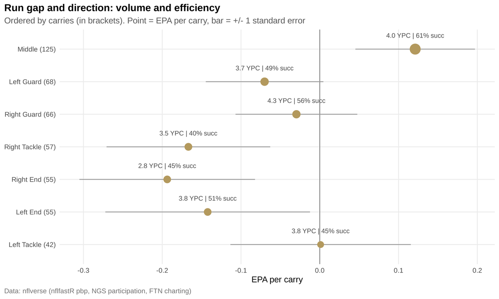

| Concept | Carries | Share | YPC | Median | Success | EPA/carry | Stuff % | Explosive % | Under center % | Top personnel |
| --- | --- | --- | --- | --- | --- | --- | --- | --- | --- | --- |
| Middle | 125 | 27% | 4.0 | 3.0 | 61% | +0.12 | 14% | 10% | 65% | 21 |
| Left Guard | 68 | 14% | 3.7 | 3.0 | 49% | -0.07 | 13% | 4% | 69% | 21 |
| Right Guard | 66 | 14% | 4.3 | 3.5 | 56% | -0.03 | 11% | 8% | 70% | 21 |
| Right Tackle | 57 | 12% | 3.5 | 2.0 | 40% | -0.17 | 26% | 9% | 86% | 21 |
| Left End | 55 | 12% | 3.8 | 3.0 | 51% | -0.14 | 24% | 13% | 78% | 21 |
| Right End | 55 | 12% | 2.8 | 2.0 | 45% | -0.19 | 25% | 7% | 78% | 21 |
| Left Tackle | 42 | 9% | 3.8 | 2.5 | 45% | +0.00 | 21% | 7% | 88% | 21 |

1 carry with no charted run gap is left out of this table.

## 5. Third-down behavior and key targets

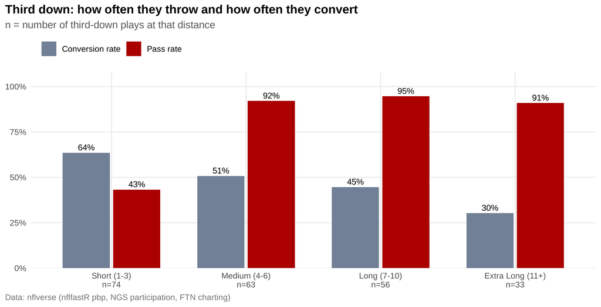

| To go | Plays | Pass % | Conv % | Conv 95% CI | EPA/play | Gun/Pistol % | Avg air yds | Sack % |
| --- | --- | --- | --- | --- | --- | --- | --- | --- |
| Short (1-3) | 74 | 43% | 64% | 52%-74% | +0.16 | 55% | 8.9 | 3% |
| Medium (4-6) | 63 | 92% | 51% | 39%-63% | +0.16 | 98% | 9.4 | 5% |
| Long (7-10) | 56 | 95% | 45% | 32%-58% | +0.39 | 98% | 9.8 | 6% |
| Extra Long (11+) | 33 | 91% | 30% | 17%-47% | +0.46 | 100% | 10.0 | 3% |

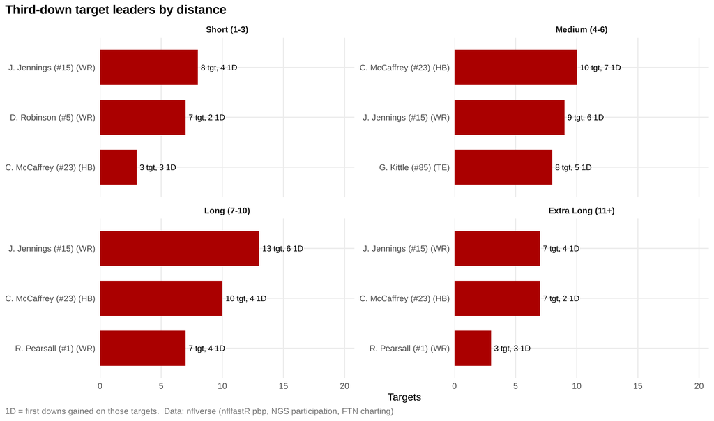

All third downs

| Player | Pos | Targets | Share | Rec | Yds | 1st downs | EPA/tgt | aDOT |
| --- | --- | --- | --- | --- | --- | --- | --- | --- |
| J. Jennings (#15) | WR | 37 | 24% | 23 | 309 | 20 | +0.71 | 10.6 |
| C. McCaffrey (#23) | HB | 30 | 19% | 24 | 255 | 16 | +0.86 | 5.2 |
| R. Pearsall (#1) | WR | 20 | 13% | 13 | 184 | 12 | +0.31 | 15.2 |
| G. Kittle (#85) | TE | 18 | 11% | 14 | 120 | 10 | +0.85 | 6.4 |
| J. Tonges (#88) | TE | 16 | 10% | 11 | 101 | 10 | +0.48 | 6.8 |
| D. Robinson (#5) | WR | 15 | 10% | 10 | 118 | 6 | -0.00 | 15.2 |
| K. Bourne (#84) | WR | 13 | 8% | 6 | 63 | 4 | -0.43 | 8.6 |
| M. Valdes-Scantling (#11) | WR | 3 | 2% | 1 | 19 | 1 | -0.08 | 16.3 |

## 6. Most effective players and how they produce

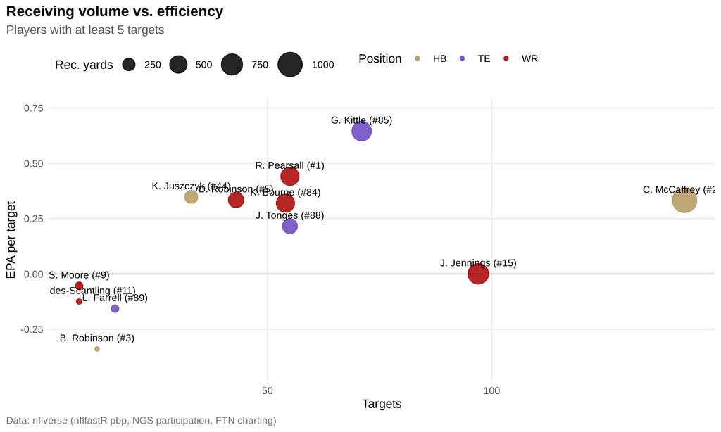

| Player | Pos | Tgt | Share | Rec | Yds | Catch % | Y/Tgt | aDOT | YAC/Rec | EPA/Tgt | 1D | Top route |
| --- | --- | --- | --- | --- | --- | --- | --- | --- | --- | --- | --- | --- |
| C. McCaffrey (#23) | HB | 143 | 24% | 113 | 1009 | 79% | 7.1 | 2.8 | 6.8 | +0.33 | 55 | QUICK OUT |
| J. Jennings (#15) | WR | 97 | 16% | 58 | 711 | 60% | 7.3 | 10.1 | 3.7 | +0.00 | 39 | QUICK OUT |
| G. Kittle (#85) | TE | 71 | 12% | 58 | 634 | 82% | 8.9 | 6.7 | 4.4 | +0.65 | 38 | QUICK OUT |
| J. Tonges (#88) | TE | 55 | 9% | 40 | 366 | 73% | 6.7 | 5.8 | 4.3 | +0.22 | 27 | HITCH/CURL |
| R. Pearsall (#1) | WR | 55 | 9% | 36 | 548 | 65% | 10.0 | 13.8 | 2.1 | +0.44 | 28 | IN/DIG |
| K. Bourne (#84) | WR | 54 | 9% | 37 | 551 | 69% | 10.2 | 11.2 | 4.5 | +0.32 | 27 | HITCH/CURL |
| D. Robinson (#5) | WR | 43 | 7% | 29 | 388 | 67% | 9.0 | 13.0 | 3.1 | +0.33 | 20 | DEEP OUT |
| K. Juszczyk (#44) | HB | 33 | 5% | 29 | 273 | 88% | 8.3 | 4.4 | 5.0 | +0.35 | 13 | QUICK OUT |
| L. Farrell (#89) | TE | 16 | 3% | 11 | 85 | 69% | 5.3 | 2.6 | 4.7 | -0.16 | 7 | SHALLOW CROSS/DRAG |
| B. Robinson (#3) | HB | 12 | 2% | 8 | 25 | 67% | 2.1 | 0.0 | 4.4 | -0.34 | 1 | SWING |
| M. Valdes-Scantling (#11) | WR | 8 | 1% | 4 | 40 | 50% | 5.0 | 11.0 | 1.0 | -0.12 | 1 | GO |
| S. Moore (#9) | WR | 8 | 1% | 5 | 87 | 62% | 10.9 | 14.9 | 5.8 | -0.05 | 5 | POST |

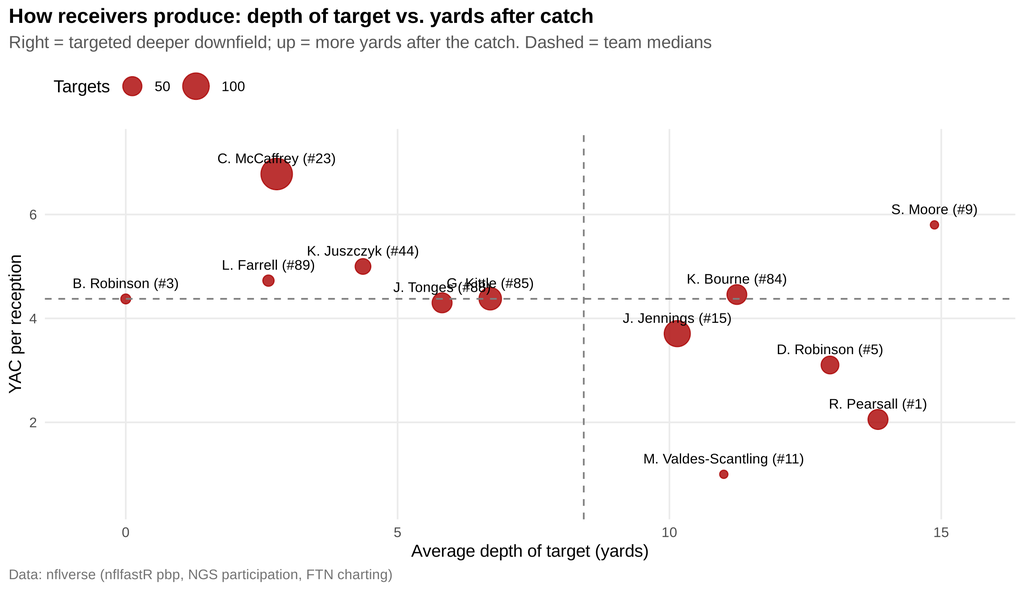

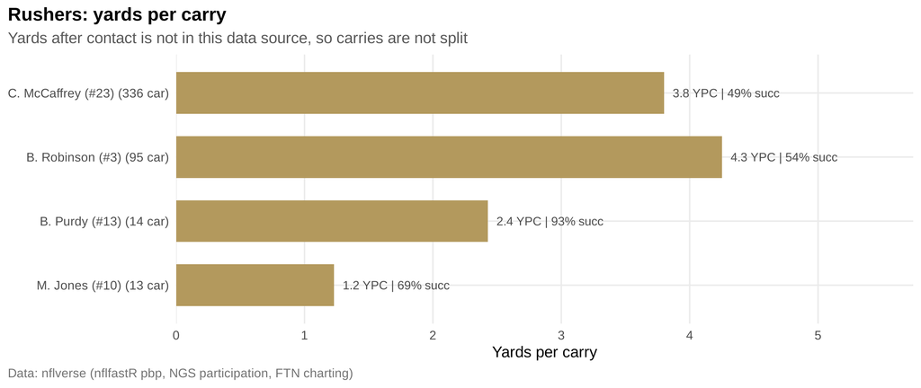

| Player | Carries | Share | Yds | YPC | Success | EPA/car | YBC | YACo | Explosive % | Stuff % | Top concept |
| --- | --- | --- | --- | --- | --- | --- | --- | --- | --- | --- | --- |
| C. McCaffrey (#23) | 336 | 72% | 1277 | 3.8 | 49% | -0.08 | n/a | n/a | 8% | 19% | Middle |
| B. Robinson (#3) | 95 | 20% | 404 | 4.3 | 54% | -0.03 | n/a | n/a | 11% | 14% | Middle |
| B. Purdy (#13) | 14 | 3% | 34 | 2.4 | 93% | +0.90 | n/a | n/a | 0% | 7% | Middle |
| M. Jones (#10) | 13 | 3% | 16 | 1.2 | 69% | +0.40 | n/a | n/a | 0% | 23% | Middle |
| K. Juszczyk (#44) | 3 | 1% | -6 | -2.0 | 0% | -2.43 | n/a | n/a | 0% | 100% | Left Guard |
| S. Moore (#9) | 3 | 1% | 14 | 4.7 | 67% | +0.18 | n/a | n/a | 33% | 0% | Right End |
| R. Pearsall (#1) | 2 | 0% | -2 | -1.0 | 0% | -0.84 | n/a | n/a | 0% | 50% | Left End |
| D. Robinson (#5) | 1 | 0% | 6 | 6.0 | 100% | +0.32 | n/a | n/a | 0% | 0% | Left End |

**Total offensive value** (rushing + receiving EPA; QB passing EPA is credited to targets):

| Player | Carries | Targets | Scrimmage yds | Rush EPA | Rec EPA | Total EPA | EPA/opp |
| --- | --- | --- | --- | --- | --- | --- | --- |
| G. Kittle (#85) | 1 | 71 | 631 | -1.0 | 45.8 | 44.9 | +0.62 |
| R. Pearsall (#1) | 2 | 55 | 546 | -1.7 | 24.3 | 22.6 | +0.40 |
| C. McCaffrey (#23) | 336 | 143 | 2286 | -26.6 | 47.5 | 20.9 | +0.04 |
| K. Bourne (#84) | 0 | 54 | 551 | 0.0 | 17.3 | 17.3 | +0.32 |
| D. Robinson (#5) | 1 | 43 | 394 | 0.3 | 14.4 | 14.7 | +0.33 |
| B. Purdy (#13) | 14 | 0 | 34 | 12.6 | 0.0 | 12.6 | +0.90 |
| J. Tonges (#88) | 0 | 55 | 366 | 0.0 | 11.9 | 11.9 | +0.22 |
| M. Jones (#10) | 13 | 0 | 16 | 5.2 | 0.0 | 5.2 | +0.40 |

## 7. Passing-game context

| Split | Value | Dropbacks | Share | EPA/play | Success | Y/P |
| --- | --- | --- | --- | --- | --- | --- |
| Play action | No | 536 | 78% | +0.16 | 53% | 6.9 |
| Play action | Yes | 153 | 22% | +0.09 | 58% | 7.3 |
| Screen | No | 647 | 94% | +0.14 | 54% | 6.9 |
| Screen | Yes | 42 | 6% | +0.27 | 55% | 7.0 |
| Pressure | Clean | 516 | 75% | +0.35 | 61% | 8.3 |
| Pressure | Pressured | 173 | 25% | -0.48 | 32% | 2.9 |

Targets by depth

| Depth | Targets | Share | Comp % | Y/Tgt | EPA/Tgt | INT % |
| --- | --- | --- | --- | --- | --- | --- |
| Behind LOS | 90 | 15% | 76% | 4.7 | -0.08 | 0% |
| Short (1-9) | 315 | 52% | 78% | 6.4 | +0.22 | 2% |
| Intermediate (10-19) | 138 | 23% | 66% | 11.3 | +0.58 | 6% |
| Deep (20+) | 59 | 10% | 44% | 12.4 | +0.35 | 8% |

Results by defensive coverage faced (5+ dropbacks)

| Coverage | Dropbacks | Share | EPA/play | Success |
| --- | --- | --- | --- | --- |
| COVER 3 | 173 | 25% | +0.25 | 62% |
| COVER 2 | 166 | 24% | +0.09 | 49% |
| COVER 1 | 151 | 22% | +0.06 | 46% |
| COVER 4 | 75 | 11% | +0.32 | 56% |
| COVER 6 | 48 | 7% | +0.07 | 60% |
| COVER 2 MAN | 36 | 5% | +0.02 | 61% |
| COVER 0 | 20 | 3% | +0.33 | 55% |
| COVER 9 | 18 | 3% | -0.18 | 44% |

## 8. Pre-snap tells and predictability

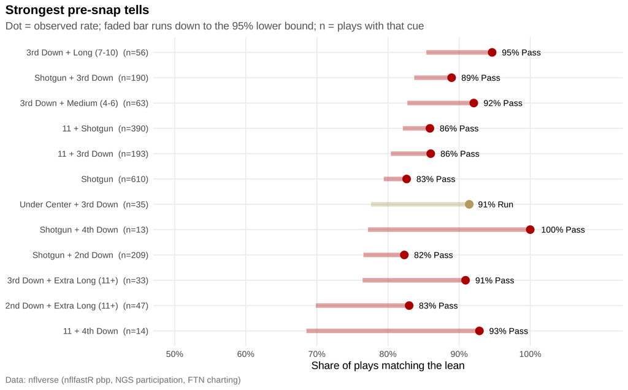

Always guessing the more common play type is right **59%** of the time. Using personnel, alignment, down and distance bucket (leave-one-out cell rates) is right **74%** of the time, a lift of **15%**.

## Methodology and data notes

How the sample was built

| Step | Plays |
| --- | --- |
| Offensive snaps in file | 1259 |
| Run or pass plays (drops penalties / no-plays) | 1200 |
| Downs 1-4 (drops PATs / 2-pt tries) | 1200 |
| Excluding garbage time | 1179 |
| Excluding QB kneels and spikes | 1158 |

### What nflverse cannot cover (or only approximates)

- Run concepts: nflverse has no blocking-scheme charting (inside zone, duo, power …). Section 4 groups runs by gap and direction instead (e.g. ‘Left Tackle’, ‘Middle’).
- PFF success codes (pff_OFFSUCCESS): not in nflverse. Success uses the standard 40/60/100 yardage rule only.
- EPA / EP: nflfastR’s public model, not PFF’s. Values are close in spirit but not identical.
- Yards after contact: not in nflverse, so the before/after-contact split for rushers is unavailable (yards per carry is shown instead).
- Receiver alignment (slot / wide / backfield): not in nflverse. ‘Main align’ is blank.
- Personnel is counted from the roster positions of the 11 players on the field (RB+FB, TE). A WR listed as TE on the roster counts as a TE. ’(*)’ = 6+ offensive linemen.
- Garbage time is approximated with win probability (second half, pre-snap WP below 0.01% or above 99.99%). Calibrated against a licensed PFF sample.
- 2-minute flag: inside the final 2:00 of either half (PFF’s 4-minute flag has no equivalent).
- Pressure is NGS ‘was_pressure’ (yes/no); time to pressure is not available.

Column names below refer to the PFF GamePBP layout the nflverse data was mapped onto.

- **Pass play / dropback:** `pff_RUNPASS = "P"`, which includes sacks and QB scrambles. **Run:** `"R"`. Penalties and no-plays (`"X"`) are removed.
- **QB alignment:** Pistol if `pff_PISTOL` is set, otherwise Shotgun if `pff_SHOTGUN` is set, otherwise Under Center.
- **Success (standard):** gaining at least 40% of the distance on 1st down, 60% on 2nd, and 100% on 3rd/4th, or earning a first down. PFF success codes are not in nflverse, so only the standard rule is used.
- **First down:** `pff_FIRSTDOWNGAINED = 1` or yards gained ≥ distance.
- **EPA:** `pff_EXPECTEDPOINTSADDED` as provided. Passing EPA is attributed to the targeted receiver.
- **Target:** a pass play with a recorded receiver, excluding sacks and scrambles. **Receiving yards:** yards gained on completions.
- **Explosive:** runs of 10+ yards, passes of 20+ yards.
- **Field zone:** `ABSOLUTEYARDLINE` is yards to the opponent’s end zone (so 1–20 is the red zone).
- **Tell:** a pre-snap cue (personnel, alignment, down, distance, or combinations) with at least 10 plays where one play type reaches 80%. The 95% lower bound uses a Wilson interval.
- **Intervals:** rates show 95% Wilson intervals; run-concept EPA shows ±1 standard error. With samples this small, most differences between groups are not statistically distinguishable; the report shows n everywhere so readers can judge.
- **Garbage time** excluded: TRUE. **2-minute drills** excluded: FALSE. **Personnel “(*)“** marks a jumbo package (an extra offensive lineman replaces a skill player); merged into the base grouping: FALSE.

**Data checks:**

- Player names from SF_2025_roster.csv (nflverse weekly rosters 2025)

Blank numeric cells (for example yards after catch on runs) are expected and listed for completeness.

Reproducibility: source file MD5 dffa638bb2fd36f893356c7dd959630e. Every table in this report is also saved as CSV and in one Excel workbook next to this file.